# Text Mining of Glassdoor Reviews

29 August 2021

## 1. Aim

The aim of this project is to classify the Glassdoor reviews of a company into various topics, and ascertain the topics that are of importance.

## 2. Activate Packages

The `tidyverse`, `rvest` and `glue` libraries are activated for Tidyverse approach of coding and web scraping respectively.

```r
pacman::p_load(tidyverse, rvest, glue)
```

## 3. Collect reviews from Glassdoor

Out of the myraid of companies from Glassdoor, the pick is my current employer, Central Provident Fund Board. Data from 2016 onwards, i.e. 5 years worth of data shall be scraped. That adds up to 20 pages worth of review. A scraper function is being defined for this task.

```r
scraping_function <- function(target_company, page_num)
{
  tryCatch({
    Sys.sleep(3)
    cat(glue::glue("Scraping page {page_num} ~ "))
    url <- glue("https://www.glassdoor.sg/Reviews/{target_company}P{page_num}.htm?sort.sortType=RD&sort.ascending=false&filter.iso3Language=eng")
    read_html(url) %>%
      html_nodes(".gdReview") %>%
      html_text() %>%
      str_match(., "Pros.+Helpful") %>%
      as_tibble(., .name_repair = ~ "V1") %>%
      mutate(V2 = str_match(V1, "Pros.+Cons")[ , 1],
             V3 = str_match(V1, "Cons.+Be the first")[ , 1],
             pros = sub(".*Pros", "", V2),
             pros = sub("Cons.*", "", pros),
             cons = sub(".*Cons", "", V3),
             cons = sub("Be.*", "", cons)
      ) %>%
      select(pros, cons) %>%
      rowid_to_column("id") %>%
      drop_na()},
    error = function(e){cat("Error in scraping: ",
                            conditionMessage(e), "\n")})
}
```

An empty dataframe `review_all` is initialized to store all the reviews that are scraped.

```r
review_all = data.frame()[ , ]
```

For loop is then written to commence the scraping process.

```r
for (i in seq(1,20,1)) {

  review <- scraping_function("Central-Provident-Fund-Board-Singapore-Reviews-EI_IE346491.0,28_IL.29,38_IN217_I", i)

  review_all <- bind_rows(review_all, review)
}
```

```
## Scraping page 1 ~ Scraping page 2 ~ Scraping page 3 ~ Scraping page 4 ~ Scraping page 5 ~ Scraping page 6 ~ Scraping page 7 ~ Scraping page 8 ~ Scraping page 9 ~ Scraping page 10 ~ Scraping page 11 ~ Scraping page 12 ~ Scraping page 13 ~ Scraping page 14 ~ Scraping page 15 ~ Scraping page 16 ~ Sc…
```

Checking out the results that are stored in the dataframe:

```r
review_all %>% DT::datatable()
```

|  | id | pros | cons |
| --- | --- | --- | --- |
| 1 | 1 | the other temp staff were really helpful and willing to teach you when you first start | A lot of drama towards the end of my contract right before I left so.. |
| 2 | 2 | Central location of office, gd pay for new grad as compare to other ministries , gd bosses to work with | Can be quite rigid in terms of implementation of ideas and takes a long time for implementation |
| 3 | 4 | A lot of areas to learning and grow | Long hours, can get burnt out easily |
| 4 | 5 | Daily smart casual attire instead of only on Fridays oh wow. | Diversity is not prevalent. Career advancement is hard for non-managers.Continue reading |
| 5 | 6 |  | Workload unevenly distributed, the good people gets a lot more work. Diverse job scope, most people find it challenging. Inefficient as a lot of red tape. Too hierarchical. Some bosses display favouri… |
| 6 | 7 | Good co-workers and working environment and fair treatment to employees |  |
| 7 | 9 | decent salary and benefits, service culture | no work life balance, excessive tape heads affect timelines |
| 8 | 10 | Good documentation for learning, reasonably good benefits | No work life balance for IT staff and higher expectations |
| 9 | 1 | Learn and gain a lot of skill set | Need to look into work life balance |
| 10 | 2 | goood for all starting out to try | not really cant think of anyContinue reading |

[output cut: 84 more lines]

## 4. Topic Modeling with tm library

Next, the libraries `tm` and `textclean` are activated. The `tm` library is used to construct a document-term matrix which describes the frequency of terms that occur in a collection of document. In this project, each row stands for a review and each column refers to the word. The values within the matrix are the frequencies of the word. The `textclean` library is required for pre-processing and cleaning of text.

```r
pacman::p_load(tm, textclean)
```

Next step is to clean, prepare the text and create the document-term matrix. A function is defined for this task.

```r
text_cleaning_function <- function(the_text) {

  the_text <- as.character(the_text)

  the_text <- the_text %>%
    str_remove_all(pattern = "[^\\s]*[0-9][^\\s]*") %>% # remove words that comprise of numeric characters
    stringr::str_remove_all(pattern = "[[:punct:]]") %>% # remove all punctiations
    stringr::str_remove_all(pattern = "Continue reading") %>% # remove "Continue Reading" which was extracted together
    stringr::str_trim() %>%
    stringr::str_squish() %>%
    textclean::replace_number(remove = T) %>%
    textclean::replace_date(replacement = "") %>%
    textclean::replace_time(replacement = "") %>%
    textclean::replace_hash(replacement = "") %>%
    textclean::replace_contraction() %>%
    textclean::replace_word_elongation() %>%
    textclean::replace_emoji() %>%
    textclean::replace_emoticon() %>%
    textclean::replace_internet_slang()

  the_text_dtm <-
    tm::VCorpus(VectorSource(the_text)) %>%
    tm::tm_map(removeWords, stopwords("en"))

  return(tm::DocumentTermMatrix(the_text_dtm))

  }
```

Call on the function to create the `document-term matrix` for the pros and cons reviews respectively.

```r
dtm_pros <- text_cleaning_function(review_all %>% select(pros) %>% drop_na())
dtm_cons <- text_cleaning_function(review_all %>% select(cons) %>% drop_na())
```

Extracting the terms that appear at least 6 times.

```r
freqterm_pros <- tm::findFreqTerms(dtm_pros, 6)
freqterm_cons <- tm::findFreqTerms(dtm_cons, 6)
```

Latent Dirichlet Allocation (LDA) is an approach used to fit topic models, where similar groups of items can be clustered together. `k` is set at 3 in this instance, in order to build 3 topics out of the text. In the later walk-through using `textmineR`, more topics will be defined for comparison and evaluation of the model.

```r
pacman::p_load(topicmodels)
```

```r
pros_lda3 <- topicmodels::LDA(dtm_pros,
                              k = 3,
                              control = list(seed = 082401))

cons_lda3 <- topicmodels::LDA(dtm_cons,
                              k = 3,
                              control = list(seed = 082402))
```

Let’s apply auto-tidy using tidy and input `beta` as argument in order to extract as per-topic-per-word probabilities. This is followed by the selecting the top 10 words per topic and visualizing them.

```r
pacman::p_load(tidytext)
```

**Pros: Per-Topic-Per-Word Probabilities**

The list of the per-topic-per-word probabilities based on frequency are extracted.

```r
pros_topic <- tidytext::tidy(pros_lda3,
                             matrix = "beta")
pros_topic
```

```
## # A tibble: 798 × 3
##    topic term           beta
##    <int> <chr>         <dbl>
##  1     1 able       0.00399
##  2     2 able       0.00164
##  3     3 able       0.00943
##  4     1 abundant   0.000716
##  5     2 abundant   0.00148
##  6     3 abundant   0.00282
##  7     1 achieve    0.00241
##  8     2 achieve    0.00110
##  9     3 achieve    0.00151
## 10     1 activities 0.00458
## # … with 788 more rows
```

Top 10 words with highest beta from each topic is selected.

```r
top_10_terms_for_pros_topic <- pros_topic %>%
  group_by(topic) %>%
  top_n(10, beta) %>%
  ungroup() %>%
  arrange(topic, -beta)
```

Visualization is created for better interpretation of the results.

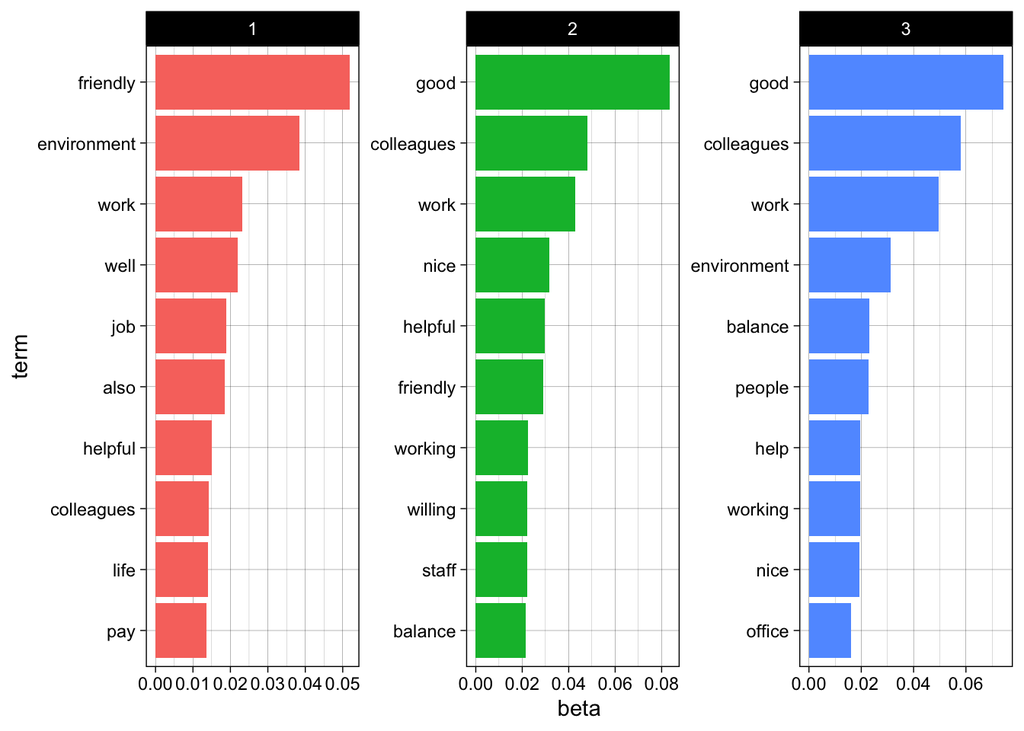

```r
top_10_terms_for_pros_topic %>%
  mutate(term = reorder_within(term, beta, topic)) %>%
  ggplot(aes(x = term,
             y = beta,
             fill = as.factor(topic)
             )
         ) +
  geom_col() +
  facet_wrap(.~topic, scales = "free", ncol = 5) +
  coord_flip() +
  scale_x_reordered() +
  theme_linedraw() +
  theme(legend.position = "none")
```

**Cons: Per-Topic-Per-Word Probabilities**

The list of the per-topic-per-word probabilities based on frequency are extracted.

```r
cons_topic <- tidytext::tidy(cons_lda3,
                             matrix = "beta")

cons_topic
```

```
## # A tibble: 1,212 × 3
##    topic term             beta
##    <int> <chr>           <dbl>
##  1     1 abusive      0.00150
##  2     2 abusive      0.00198
##  3     3 abusive      0.00100
##  4     1 academic     0.00298
##  5     2 academic     0.00106
##  6     3 academic     0.000443
##  7     1 achievements 0.00151
##  8     2 achievements 0.000944
##  9     3 achievements 0.00202
## 10     1 adapt        0.00101
## # … with 1,202 more rows
```

Top 10 words with highest beta from each topic is selected.

```r
top_10_terms_for_cons_topic <- cons_topic %>%
  group_by(topic) %>%
  top_n(10, beta) %>%
  ungroup() %>%
  arrange(topic, -beta)
```

Visualization is created for better interpretation of the results.

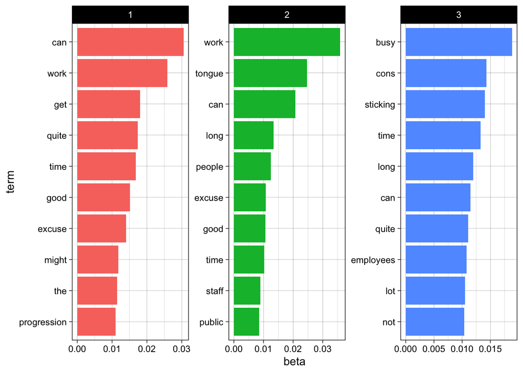

```r
top_10_terms_for_cons_topic %>%
  mutate(term = reorder_within(term, beta, topic)) %>%
  ggplot(aes(x = term,
             y = beta,
             fill = as.factor(topic)
             )
         ) +
  geom_col() +
  facet_wrap(.~topic, scales = "free", ncol = 5) +
  coord_flip() +
  scale_x_reordered() +
  theme_linedraw() +
  theme(legend.position = "none")
```

In summmary, under the analysis for pros review, topic 1 seems to suggest a good environment and pay. Topic 2 implies that colleagues are helpful, friendly and nice, and topic 3 seems to be work life balance and nice people or environment.

As for cons review, topic 1 seems to suggest a topic regarding time and progression, and couldn’t really make out topic 2. Topic 3 seems to be a theme on how busy the employees are.

However, the probabilities are not conclusive in terms of the topics which are more significant than others. This will be further analyzed in the next segment using the `textmineR` library, where the model evaluation will be covered.

## 5. Topic Modeling with textmineR library

This is the more preferred approach to topic modeling. The `textmineR` library is first activated. A new function `text_cleaning_function_2` is defined for pre-processing of text.

```r
text_cleaning_function_2 <- function(your_text)
{
  your_text <- as.character(your_text)

  your_text <- your_text %>%
    stringr::str_remove_all(pattern = "[^\\s]*[0-9][^\\s]*") %>%
    stringr::str_remove_all(pattern = "[[:punct:]]") %>%
    stringr::str_remove_all(pattern = "Continue reading") %>%
    stringr::str_trim() %>%
    stringr::str_squish() %>%
    textclean::replace_number(remove = T) %>%
    textclean::replace_date(replacement = "") %>%
    textclean::replace_time(replacement = "") %>%
    textclean::replace_hash(replacement = "") %>%
    textclean::replace_contraction() %>%
    textclean::replace_word_elongation() %>%
    textclean::replace_emoji() %>%
    textclean::replace_emoticon() %>%
    textclean::replace_internet_slang()

  return(as.data.frame(your_text))
}
```

The data under the `review_all` dataframe are then pre-processed using `text_cleaning_function_2` and stored under `pros_cleaned` and `cons_cleaned`.

```r
pros_cleaned <- text_cleaning_function_2(review_all$pros) %>% rowid_to_column("id")
cons_cleaned <- text_cleaning_function_2(review_all$cons) %>% rowid_to_column("id")
```

Next step is to create the document-term matrix using the `CreateDtm` function within the `textmineR` library.

```r
set.seed(082403)
dtm_pros_cleaned <- textmineR::CreateDtm(doc_vec = pros_cleaned$your_text,
                                         doc_names = pros_cleaned$id,
                                         ngram_window = c(1, 2),
                                         stopword_vec = stopwords("en"),
                                         verbose = F)

dtm_pros_cleaned <- dtm_pros_cleaned[ , colSums(dtm_pros_cleaned) > 2] # choosing words with frequency more than 2

set.seed(082404)
dtm_cons_cleaned <- textmineR::CreateDtm(doc_vec = cons_cleaned$your_text,
                                         doc_names = cons_cleaned$id,
                                         ngram_window = c(1, 2),
                                         stopword_vec = stopwords("en"),
                                         verbose = F)


dtm_cons_cleaned <- dtm_cons_cleaned[ , colSums(dtm_cons_cleaned) > 2] # choosing words with frequency more than 2
```

Fitting the LDA model using `textmineR`. For this we will select 12 topics for a more effective comparison of the various topics in the subsequent segments.

```r
set.seed(082405)
lda_model_pros_cleaned <- textmineR::FitLdaModel(dtm = dtm_pros_cleaned,
                                                 k = 12,
                                                 iterations = 500,
                                                 burnin = 200,
                                                 alpha = 0.1,
                                                 beta = 0.05,
                                                 optimize_alpha = T,
                                                 calc_likelihood = T,
                                                 calc_r2 = T,
                                                 calc_coherence = T)


set.seed(082406)
lda_model_cons_cleaned <- textmineR::FitLdaModel(dtm = dtm_cons_cleaned,
                                                 k = 12,
                                                 iterations = 500,
                                                 burnin = 200,
                                                 alpha = 0.1,
                                                 beta = 0.05,
                                                 optimize_alpha = T,
                                                 calc_likelihood = T,
                                                 calc_r2 = T,
                                                 calc_coherence = T)
```